# Loading and preprocessing the data

##Reproducible Research: Peer Assessment 1. Activity monitor analysis

## Loading and preprocessing the data

The data to work with is included in this github project, the first step would be to unzip the data and place it under the `data/` directory and load it into R. **Note**: the `data` directory won't be commited to github.

```r
unzip('activity.zip', exdir='data/')
data <- fread('data/activity.csv')
data$date <- as.Date(data$date, format='%Y-%m-%d')
```

## What is mean total number of steps taken per day?

We add the total number of steps per day and group them by the date. A histogram is created to illustrate the total number of steps.

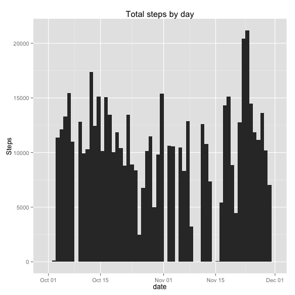

```r
totalStepsByDay <- data[,.(total=sum(steps)), .(date)]
ggplot(totalStepsByDay, aes(x=date, weight=total)) +
    geom_histogram(binwidth=1) +
    labs(title='Total steps by day', y='Steps')
```

We will also report the mean and median steps taken by day. We first ignore the entries with `NA` steps.

```r
stepsByDay <- data[!is.na(steps),
                   .(
                     meanDay=mean(steps, na.rm=T),
                     medianDay=median(steps, na.rm=T)
                     ), .(date)]
```

Notice that some dates are missing, this is because there's no data in those days.

| date | meanDay | medianDay |
| --- | --- | --- |
| 2012-10-02 | 0.44 | 0.00 |
| 2012-10-03 | 39.42 | 0.00 |
| 2012-10-04 | 42.07 | 0.00 |
| 2012-10-05 | 46.16 | 0.00 |
| 2012-10-06 | 53.54 | 0.00 |
| 2012-10-07 | 38.25 | 0.00 |
| 2012-10-09 | 44.48 | 0.00 |
| 2012-10-10 | 34.38 | 0.00 |
| 2012-10-11 | 35.78 | 0.00 |
| 2012-10-12 | 60.35 | 0.00 |
| 2012-10-13 | 43.15 | 0.00 |
| 2012-10-14 | 52.42 | 0.00 |
| 2012-10-15 | 35.20 | 0.00 |
| 2012-10-16 | 52.38 | 0.00 |
| 2012-10-17 | 46.71 | 0.00 |
| 2012-10-18 | 34.92 | 0.00 |
| 2012-10-19 | 41.07 | 0.00 |
| 2012-10-20 | 36.09 | 0.00 |
| 2012-10-21 | 30.63 | 0.00 |
| 2012-10-22 | 46.74 | 0.00 |
| 2012-10-23 | 30.97 | 0.00 |
| 2012-10-24 | 29.01 | 0.00 |
| 2012-10-25 | 8.65 | 0.00 |
| 2012-10-26 | 23.53 | 0.00 |
| 2012-10-27 | 35.14 | 0.00 |
| 2012-10-28 | 39.78 | 0.00 |
| 2012-10-29 | 17.42 | 0.00 |
| 2012-10-30 | 34.09 | 0.00 |
| 2012-10-31 | 53.52 | 0.00 |
| 2012-11-02 | 36.81 | 0.00 |
| 2012-11-03 | 36.70 | 0.00 |
| 2012-11-05 | 36.25 | 0.00 |
| 2012-11-06 | 28.94 | 0.00 |
| 2012-11-07 | 44.73 | 0.00 |
| 2012-11-08 | 11.18 | 0.00 |
| 2012-11-11 | 43.78 | 0.00 |
| 2012-11-12 | 37.38 | 0.00 |
| 2012-11-13 | 25.47 | 0.00 |
| 2012-11-15 | 0.14 | 0.00 |
| 2012-11-16 | 18.89 | 0.00 |
| 2012-11-17 | 49.79 | 0.00 |
| 2012-11-18 | 52.47 | 0.00 |
| 2012-11-19 | 30.70 | 0.00 |
| 2012-11-20 | 15.53 | 0.00 |
| 2012-11-21 | 44.40 | 0.00 |
| 2012-11-22 | 70.93 | 0.00 |
| 2012-11-23 | 73.59 | 0.00 |
| 2012-11-24 | 50.27 | 0.00 |
| 2012-11-25 | 41.09 | 0.00 |
| 2012-11-26 | 38.76 | 0.00 |
| 2012-11-27 | 47.38 | 0.00 |
| 2012-11-28 | 35.36 | 0.00 |
| 2012-11-29 | 24.47 | 0.00 |

## What is the average daily activity pattern?

We want to know on average how many steps are given on a time period. Remember, the data set contains a variable called `interval` which is the 5 minute period where the read was taken, for example, 0 represents 0:00, 1455 represents 14:55, and so on.

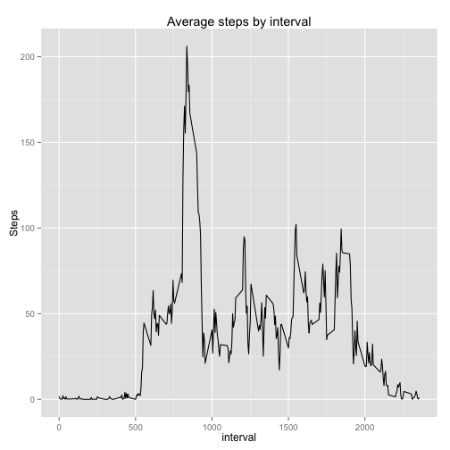

```r
meanByInterval <- data[,.(avgSteps=mean(steps, na.rm=T)), .(interval)]
ggplot(meanByInterval, aes(interval, avgSteps)) +
    geom_line() +
    labs(title='Average steps by interval', y='Steps')
```

We can see that the interval with the max average steps is the 835 interval with an average of 206.1698113.

## Imputing missing values

This data set contains a total of 2304 `NA` values in the steps variables. In order to fix this we will replace those `NA`s with the median of the day. In the days where the median cannot be calculated (there are no reading for that specific day) we will set the steps to 0.

Going from `NA`s to 0 is probably not the optimal. One improvement for this would be to calculate the mean of the observations of other days with observation, I'd assume that a similar routine is followed for example in every Monday.

The steps to replace `NA`s with the media is as follow.

1. Replicate our data set.
2. Detect the days that have `NA`s in it.
3. Apply the function `replaceNAs` which will do the following
   1. It will get the median using the mean/median set displayed above.
   2. If the row doesn't exist we default to a median 0
   3. The selected median is applied to all `NA`s steps.

```r
replaceNAs <- function(dayDate) {
    dayMedian <- 0
    steps <- stepsByDay[date==dayDate]

    # If we don't have a row, then  day median is NA (there are no steps recorded
    # in the whole day, we set the rowMedian to 0
    if (nrow(steps) > 0) {
        dayMedian <- steps$medianDay
    }

    imputed[date==dayDate & is.na(steps), steps:=dayMedian]
}

# We will create a copy of the data
imputed <- data.table(data)

# We detect the dates with NAs in it
nasDates <- imputed[is.na(steps), unique(date)]

a <- lapply(nasDates, replaceNAs)
```

To see the histogram of this values we add the steps and display.

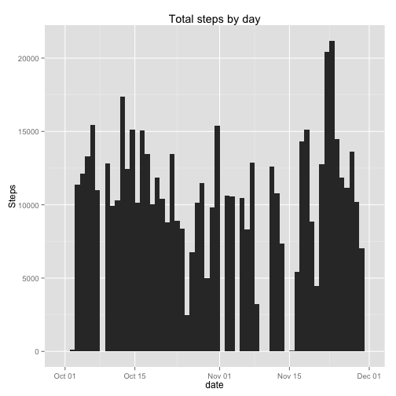

```r
imputedTotals <- imputed[,.(total=sum(steps)), .(date)]
ggplot(imputedTotals, aes(x=date, weight=total)) +
    geom_histogram(binwidth=1) +
    labs(title='Total steps by day', y='Steps')
```

What's the difference between this histogram and the previous without the `NA`s replace? We will take both histograms data and calculate the difference. The table below shows the results.

```r
totalsDifference <- merge(totalStepsByDay, imputedTotals, by='date')
fixedDiff <- totalsDifference[,
              .(date,
                diff=abs(ifelse(is.na(total.x), 0, total.x) - total.y)
                )]
```

Basically, replacing `NA`s with the median, wouldn't change the results that we've seen so far.

| date | diff |
| --- | --- |
| 2012-10-01 | 0.00 |
| 2012-10-02 | 0.00 |
| 2012-10-03 | 0.00 |
| 2012-10-04 | 0.00 |
| 2012-10-05 | 0.00 |
| 2012-10-06 | 0.00 |
| 2012-10-07 | 0.00 |
| 2012-10-08 | 0.00 |
| 2012-10-09 | 0.00 |
| 2012-10-10 | 0.00 |
| 2012-10-11 | 0.00 |
| 2012-10-12 | 0.00 |
| 2012-10-13 | 0.00 |
| 2012-10-14 | 0.00 |
| 2012-10-15 | 0.00 |
| 2012-10-16 | 0.00 |
| 2012-10-17 | 0.00 |
| 2012-10-18 | 0.00 |
| 2012-10-19 | 0.00 |
| 2012-10-20 | 0.00 |
| 2012-10-21 | 0.00 |
| 2012-10-22 | 0.00 |
| 2012-10-23 | 0.00 |
| 2012-10-24 | 0.00 |
| 2012-10-25 | 0.00 |
| 2012-10-26 | 0.00 |
| 2012-10-27 | 0.00 |
| 2012-10-28 | 0.00 |
| 2012-10-29 | 0.00 |
| 2012-10-30 | 0.00 |
| 2012-10-31 | 0.00 |
| 2012-11-01 | 0.00 |
| 2012-11-02 | 0.00 |
| 2012-11-03 | 0.00 |
| 2012-11-04 | 0.00 |
| 2012-11-05 | 0.00 |
| 2012-11-06 | 0.00 |
| 2012-11-07 | 0.00 |
| 2012-11-08 | 0.00 |
| 2012-11-09 | 0.00 |
| 2012-11-10 | 0.00 |
| 2012-11-11 | 0.00 |
| 2012-11-12 | 0.00 |
| 2012-11-13 | 0.00 |
| 2012-11-14 | 0.00 |
| 2012-11-15 | 0.00 |
| 2012-11-16 | 0.00 |
| 2012-11-17 | 0.00 |
| 2012-11-18 | 0.00 |
| 2012-11-19 | 0.00 |
| 2012-11-20 | 0.00 |
| 2012-11-21 | 0.00 |
| 2012-11-22 | 0.00 |
| 2012-11-23 | 0.00 |
| 2012-11-24 | 0.00 |
| 2012-11-25 | 0.00 |
| 2012-11-26 | 0.00 |
| 2012-11-27 | 0.00 |
| 2012-11-28 | 0.00 |
| 2012-11-29 | 0.00 |
| 2012-11-30 | 0.00 |

## Are there differences in activity patterns between weekdays and weekends?

```r
imputed[,weekday:=as.factor(ifelse(as.POSIXlt(date)$wday > 5, 'weekend', 'weekday'))]
```

```
##        steps       date interval weekday
##     1:     0 2012-10-01        0 weekday
##     2:     0 2012-10-01        5 weekday
##     3:     0 2012-10-01       10 weekday
##     4:     0 2012-10-01       15 weekday
##     5:     0 2012-10-01       20 weekday
##    ---
## 17564:     0 2012-11-30     2335 weekday
## 17565:     0 2012-11-30     2340 weekday
## 17566:     0 2012-11-30     2345 weekday
## 17567:     0 2012-11-30     2350 weekday
## 17568:     0 2012-11-30     2355 weekday
```

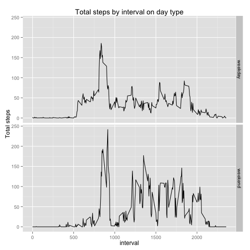

```r
weekDay <- imputed[,.(total=mean(steps)), .(interval, weekday)]
ggplot(weekDay, aes(interval, total)) +
    geom_line() +
    facet_grid(weekday ~ .) +
    labs(title='Total steps by interval on day type', y='Total steps')
```